# Introduction to R functionality – Part 3

**Author:** Christina Dimitriadou

**Date:** 12/04/2021

This is the third of 5 introductory notebooks to statistics with R. In the previous two notebooks I covered a few basic concepts on:

- Variables, vectors, sequences
- Functions
- R scripts
- Data frames
- Installing and loading packages

In this notebook I will cover essential information on plotting and data visualisation with **ggplot2** and **R base**.

## Plotting with R – Intro to ggplot2

In the previous notebook we already saw R’s built-in plotting function `plot()`. This is one of the most frequently used plotting function of type generic (meaning it comes with R base, we do not need to install it). It produces plots that are dependent to the class of the first argument (x).

**Let’s assume that we want to plot: `plot(x,y)`:

- If `x` and `y` are both vectors, `plot(x,y)` will produce a scatterplot of *y* against *x*.
- If `x` is a time-series, `plot(x,y)` will produce a time-series plot.
- If `x` is a factor, then `plot(x,y)` will produce a box-plot.

A more recent and powerful library for creating plots is `ggplot2`. This package/library is like an R mini-language (meaning that it has its own way of typing the commands within the R environment). This package was created by Hadley Wickham and it implements ideas based on Leland Wilkinson’s [The Grammar of Graphics](https://www.springer.com/gp/book/9780387245447).

Here, I will cover some basic aspects of the `ggplot` syntax, but more information can be found in the [online documentation](https://ggplot2.tidyverse.org)

We saw int he previous notebook that `ggplot2()` is part of *Tidyverse*, so loading the *Tidyverse* will also load *ggplot* automatically:

```r
library(tidyverse)
```

Or if *ggplot* was installed independently of *Tidyverse*:

```r
library(ggplot2)
```

We will keep using this simple **reaction times** dataset from the previous notebook, lo let’s load it:

```r
# change this to your own path (the path of where you have stored the data set)
data = read.csv("~/Desktop/intro_toR/intro_data/rt_data/allcategoryrts.csv", header=FALSE, sep=";")

data # to visualise

# add headers
colnames(data) = c("subj", "rt", "classes", "cat", "gender", "category")

# convert categorical variables into factors
# classes - class
data$class = factor(data$classes,
                    levels = c("1", "2"),
                    labels = c("living", "non-living"))

# category - fcat
data$fcat = factor(data$category,
                   levels = c("1", "2", "3", "4"),
                   labels = c("objects", "scenes", "animals", "humans"))

# gender - fgender
data$fgender = factor(data$gender,
                      levels = c("1", "2"),
                      labels = c("male", "female"))
```

Note that we converted the categorical variables to factors in order to visualise and manipulate them easier.

### Pieces of a ggplot()

In order to produce a plot with `ggplot2()` we need three things:

- A data-frame with the data that we want to visualise (df)
- A way to translate the columns/vectors of the *df* into colours, positions, sizes, grouping (aesthetics or aes)
- The actual things that we want to display (the geometric object)

Let’s make a first `ggplot`:

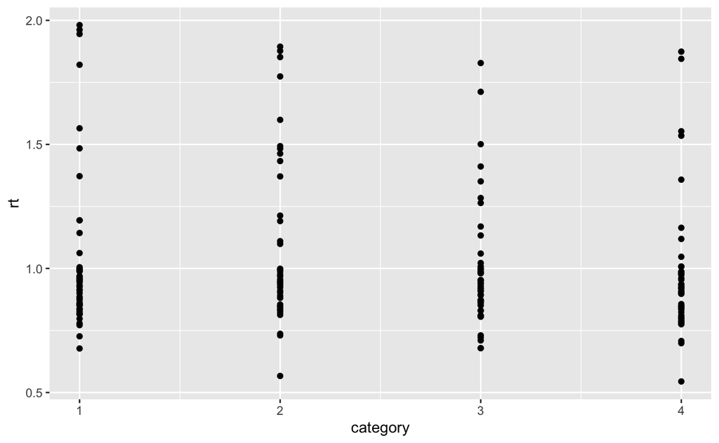

```r
ggplot(data, aes(x=category, y=rt)) +
  geom_point()
```

Let’s explain the above command: Note that we use the `geom_point` function to create a scatterplot and in the `asc()` we give the *x* and *y* positions. In order to initialise a `ggplot` we give the dataframe as the first argument and `aes`. We could also provide specific arguments for colour, size, etc. `aes` is an example of non-standard evaluation and arguments of `aes` can refer to columns/vectors of the dataframe directly. Once we have the base: `ggplot()`, we then add layers of graphics using `+` and the `geom_` functions.

The above is a basic illustration, we can use more aesthetics either numeric or categorical:

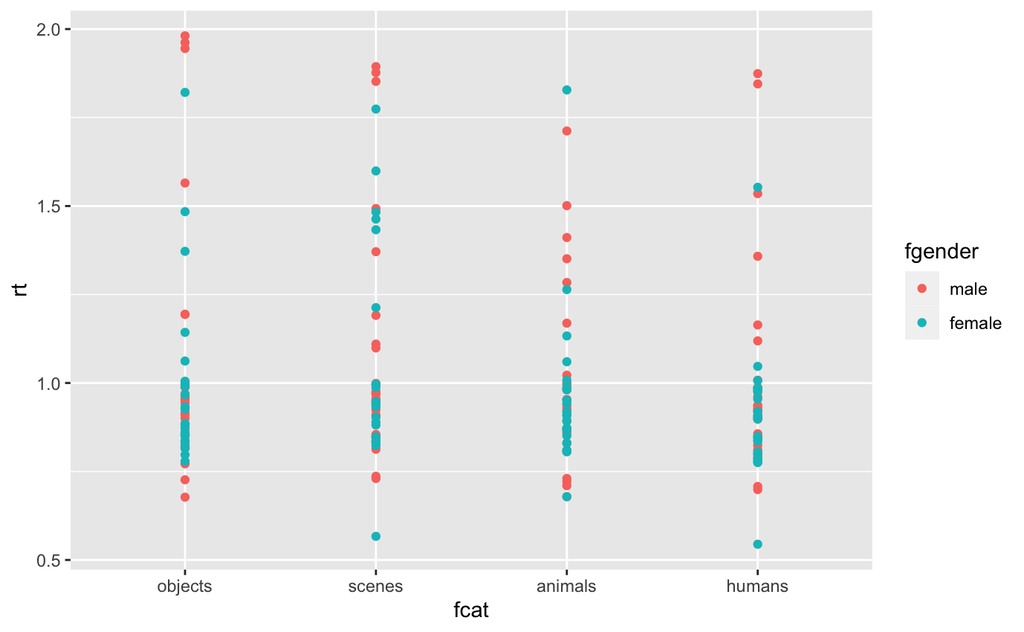

```r
ggplot(data, aes(x=fcat, y=rt, color=fgender)) +
  geom_point()
```

### First challenge using `ggplot()`

Create a `ggplot()` using:

- *rt* as the x position
- *class* as the y position
- *fcat* as colour

### More geoms with `ggplot()`

Given that we have a lot of factors in this dataset, lets plot boxplots:

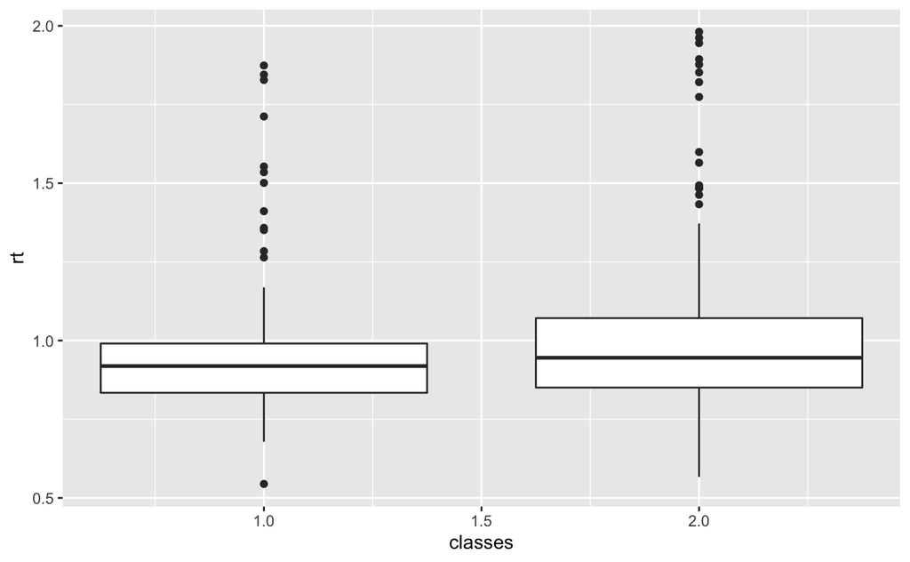

```r
ggplot(data, aes(x=classes, y=rt, group=classes)) +
  geom_boxplot()
```

We can also plot data as lines:

```r
ggplot(data, aes(x=rt, y=cat, group=category, color=subj)) +
  geom_line()
```

[output not shown]

We can also use a bar plot:

```r
ggplot(data, aes(fcat)) +
  geom_bar()
```

[output not shown]

or map the **fcat** to y instead to flip the orientation

```r
ggplot(data, aes(y=fcat)) +
  geom_bar()
```

[output not shown]

We can also group bar plots. For example, the classes column defines living and non-living, but these are further defined as objects, scenes, etc in the category column:

```r
ggplot(data, aes(x=classes, fill=fcat)) +
  geom_bar()
```

[output not shown]

### Print or Save a `ggplot()`

We can store plots in variables and print them:

```r
plt = ggplot(data, aes(classes)) + geom_bar()

plt #
```

This will plot the “plt” object on the console not in the plots section where we can save them. In order to save the plot as a .png or.csv file:

```r
# first print the plot:
print(plt)

# save the plot
ggsave("test.png", p) # this will save the plot as a png file in your home directory
```